# “Telco Churn Classification”

Popoola Olawale

2023-06-27

Predicting Consumer Churn of Telecommunication Firm Using Classification Techniques *Logistic Regression, Decision Tree and Random Forest*

Customer churn happens when customers stop using a product or service from a product. It is a loss for the business. This can lead to loss of profit and market share. This analysis can help a company know more about their customers behaviour and enables companies to implement strategies that increase customer retention rates.

The data to be used is of Telecom industry and gotten from Kaggle. The telecom industry is susceptible to Churn so it is a good example. This analysis mirrors works that have been done before me.

**DATA PREPROCESSING**

```r
library("dplyr")
library("gridExtra")
library("ggthemes")
library("caret")
library("MASS")
library("randomForest")
library("partykit")
Telco <- read.csv("TelcoCustomerChurn.csv", header = TRUE, stringsAsFactors = TRUE)
```

I attempt to find if there are missing values in the dataset

```r
sapply(Telco, function(x) sum(is.na(x)))
```

```
##       customerID           gender    SeniorCitizen          Partner
##                0                0                0                0
##       Dependents           tenure     PhoneService    MultipleLines
##                0                0                0                0
##  InternetService   OnlineSecurity     OnlineBackup DeviceProtection
##                0                0                0                0
##      TechSupport      StreamingTV  StreamingMovies         Contract
##                0                0                0                0
## PaperlessBilling    PaymentMethod   MonthlyCharges     TotalCharges
##                0                0                0               11
##            Churn
##                0
```

I remove the missing values

```r
Telco <- Telco[complete.cases(Telco),]
```

# Data wrangling.

Attempting to change some values in col[,c10:15] from #1) “No internet service” to “No”

```r
col_recode <- c(10:15)
for (i in 1:ncol(Telco[,col_recode])){
   Telco[,col_recode][,i][Telco[,col_recode][,i] == "No internet service"] <- "No"
}
```

#2) Attempting to change the value in Telco$Multiple lines; from “No phone Service” to No

```r
Telco$MultipleLines[Telco$MultipleLines == "No phone service"] <- "No"
```

#3) Attempting to change the value in Telco$SeniorCitizens

```r
Telco$SeniorCitizen[Telco$SeniorCitizen == 0] <- "No"
Telco$SeniorCitizen[Telco$SeniorCitizen == 1] <- "Yes"
```

#4 I remove the first column of the dataset as the Customer Id is not useful for this classification analysis

```r
Telco <- Telco[,-1]
```

**Exploratory Data analysis and Feature selection**

```
_Correlation between numeric variables_
```

```r
numeric_Telco <- select_if(Telco, is.numeric)
```

The Tenure Variable is used to quantify the number of months so I remove it.

```r
numeric_Telco <- numeric_Telco[,-1]
```

I use correlation to check the similarities between Monthly Charges and Total Charges

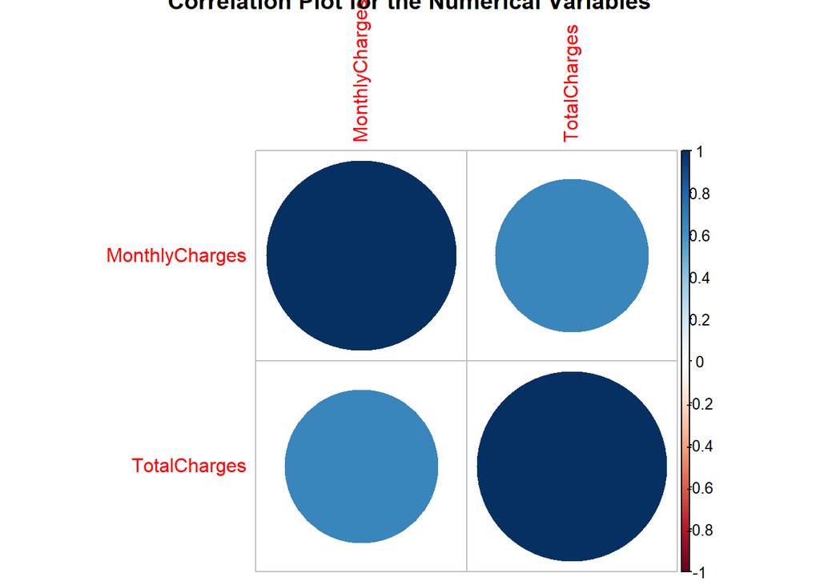

```r
corr.matrix <- cor(numeric_Telco)
corrplot::corrplot(corr.matrix, main =
  "Correlation Plot for the Numerical Variables")
```

#The Monthly Charges and Total Charges are correlated. So one of them will be removed

```r
Telco <- Telco[,-19]
```

**Bar charts Visualisation for categorical variables**

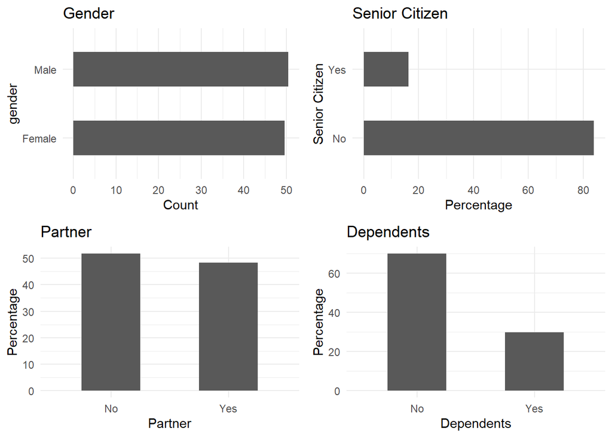

```r
p1 <- ggplot(data = Telco)+
  geom_bar(mapping = aes(x = gender,
            y = 100*(..count..)/sum(..count..)),
           width = 0.5)+
  ggtitle("Gender")+
  ylab("Count")+
  theme_minimal()+
  coord_flip()


p2 <- ggplot(Telco, aes(x=SeniorCitizen)) + ggtitle("Senior Citizen") + xlab("Senior Citizen") +
  geom_bar(aes(y = 100*(..count..)/sum(..count..)), width = 0.5) + ylab("Percentage") + coord_flip() + theme_minimal()

p3 <- ggplot(Telco)+
  geom_bar(mapping = aes(x = Partner,
  y = 100*(..count..)/sum(..count..)),
  width = 0.5)+
  ggtitle("Partner")+
  xlab("Partner")+
  ylab("Percentage")+
  theme_minimal()

p4 <- ggplot(Telco)+
  geom_bar(mapping = aes(x = Dependents,
                         y = 100*(..count..)/sum(..count..)),
           width = 0.5)+
  ggtitle("Dependents")+
  xlab("Dependents")+
  ylab("Percentage")+
  theme_minimal()

grid.arrange(p1,p2,p3,p4, ncol =2)
```

The remaining barcharts were constructed for the other variables using the above code.

**Classification algorithms**

*I begin with the logistic regression*

#Data Splitting

```r
intrain <- createDataPartition(Telco$Churn,
            p = 0.7, list = FALSE)
set.seed(2017)

training <- Telco[intrain,]
testing <-  Telco[-intrain,]

dim(training); dim(testing)
```

```
## [1] 4924   19
```

```
## [1] 2108   19
```

#Fitting the Logistic Regression Model

```r
LogModel <- glm(Churn ~ ., family = binomial
      (link= "logit"), data = training)
summary(LogModel)
```

```
##
## Call:
## glm(formula = Churn ~ ., family = binomial(link = "logit"), data = training)
##
## Deviance Residuals:
##     Min       1Q   Median       3Q      Max
## -2.0020  -0.6629  -0.2795   0.6909   3.2205
##
## Coefficients:
##                                       Estimate Std. Error z value Pr(>|z|)
## (Intercept)                           0.101837   0.977839   0.104   0.9171
## genderMale                           -0.040651   0.077995  -0.521   0.6022
## SeniorCitizenYes                      0.248284   0.102309   2.427   0.0152 *
## PartnerYes                            0.021551   0.093812   0.230   0.8183
## DependentsYes                        -0.192206   0.108356  -1.774   0.0761 .
## tenure                               -0.034798   0.002907 -11.971  < 2e-16 ***
## PhoneServiceYes                      -0.256194   0.785413  -0.326   0.7443
## MultipleLinesYes                      0.419687   0.214705   1.955   0.0506 .
## InternetServiceFiber optic            1.176088   0.967026   1.216   0.2239
## InternetServiceNo                    -1.213819   0.976510  -1.243   0.2139
## OnlineSecurityYes                    -0.422431   0.217488  -1.942   0.0521 .
## OnlineBackupYes                      -0.072480   0.212119  -0.342   0.7326
## DeviceProtectionYes                   0.017973   0.214080   0.084   0.9331
## TechSupportYes                       -0.322819   0.219838  -1.468   0.1420
## StreamingTVYes                        0.347404   0.394129   0.881   0.3781
## StreamingMoviesYes                    0.447216   0.395224   1.132   0.2578
## ContractOne year                     -0.545642   0.127177  -4.290 1.78e-05 ***
## ContractTwo year                     -1.505338   0.228877  -6.577 4.80e-11 ***
## PaperlessBillingYes                   0.357051   0.089319   3.997 6.40e-05 ***
## PaymentMethodCredit card (automatic) -0.034362   0.137491  -0.250   0.8026
## PaymentMethodElectronic check         0.265773   0.114730   2.317   0.0205 *
## PaymentMethodMailed check             0.022975   0.137313   0.167   0.8671
## MonthlyCharges                       -0.011628   0.038445  -0.302   0.7623
## ---
## Signif. codes:  0 '***' 0.001 '**' 0.01 '*' 0.05 '.' 0.1 ' ' 1
##
## (Dispersion parameter for binomial family taken to be 1)
##
##     Null deviance: 5702.8  on 4923  degrees of freedom
## Residual deviance: 4047.1  on 4901  degrees of freedom
## AIC: 4093.1
##
## Number of Fisher Scoring iterations: 6
```

#Feature Analysis

#Analysing variance with Anova

```r
anova(LogModel, test = "Chisq")
```

```
## Analysis of Deviance Table
##
## Model: binomial, link: logit
##
## Response: Churn
##
## Terms added sequentially (first to last)
##
##
##                  Df Deviance Resid. Df Resid. Dev  Pr(>Chi)
## NULL                              4923     5702.8
## gender            1     1.17      4922     5701.6 0.2800899
## SeniorCitizen     1   122.82      4921     5578.8 < 2.2e-16 ***
## Partner           1   119.71      4920     5459.1 < 2.2e-16 ***
## Dependents        1    37.31      4919     5421.8 1.009e-09 ***
## tenure            1   593.17      4918     4828.6 < 2.2e-16 ***
## PhoneService      1     1.03      4917     4827.6 0.3110300
## MultipleLines     1   139.53      4916     4688.0 < 2.2e-16 ***
## InternetService   2   440.72      4914     4247.3 < 2.2e-16 ***
## OnlineSecurity    1    46.53      4913     4200.8 9.037e-12 ***
## OnlineBackup      1     2.08      4912     4198.7 0.1490996
## DeviceProtection  1     0.49      4911     4198.2 0.4825067
## TechSupport       1    26.47      4910     4171.7 2.676e-07 ***
## StreamingTV       1    16.76      4909     4155.0 4.235e-05 ***
## StreamingMovies   1    12.90      4908     4142.1 0.0003292 ***
## Contract          2    66.93      4906     4075.2 2.925e-15 ***
## PaperlessBilling  1    17.39      4905     4057.8 3.052e-05 ***
## PaymentMethod     3    10.53      4902     4047.2 0.0145864 *
## MonthlyCharges    1     0.09      4901     4047.1 0.7622961
## ---
## Signif. codes:  0 '***' 0.001 '**' 0.01 '*' 0.05 '.' 0.1 ' ' 1
```

Analysing the deviance table, we can see the drop in deviance when adding each variable one at a time. Tenure and Internet Service significantly reduces the residual variance.

#Assessing the predictive ability of the Logistic Regression model

```r
testing$Churn <- as.character(testing$Churn)

testing$Churn[testing$Churn == "No"] <- 0
testing$Churn[testing$Churn == "Yes"] <- 1
testing$Churn <- as.factor(testing$Churn)

fitted.results <- predict(LogModel,newdata = testing, type = 'response')

print("Confusion Matrix for Logistic Regression"); table(testing$Churn, fitted.results > 0.5)
```

```
## [1] "Confusion Matrix for Logistic Regression"
```

```
##
##     FALSE TRUE
##   0  1393  155
##   1   281  279
```

```r
glm_accuracy <- (1397+305)/(1397+151+255+305)
glm_accuracy
```

[output not shown]

**Decision Tree**

We are going to use three variables for Decision Trees, they are “Contract”, “Tenure’, and PaperlessBilling

#Visualisation

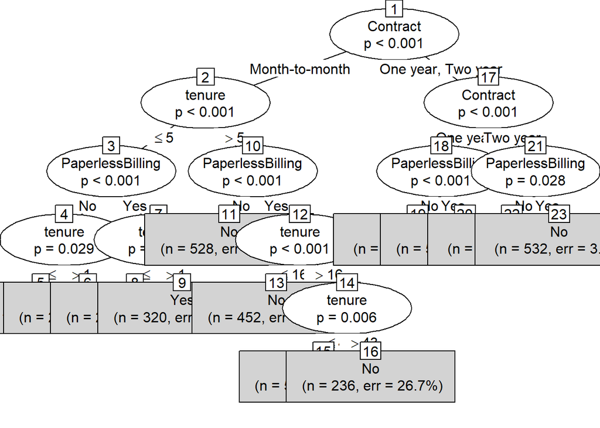

```r
tree <- ctree(Churn ~ Contract+tenure+PaperlessBilling, training)
plot(tree, type = "simple")
```

#From the plot

1. Contract is the most important feature to churn or not to churn. 2 Users on a year or two contract are less likely to churn whether they are on paper billing.
2. Users with lesss than tenure of 2 months are the most likely to churn.

# Decision Tree Confusion Matrix

```r
pred_tree <- predict(tree, testing)
print("confusion Matrix for Decision Tree");table(Predicted = pred_tree, Actual = testing$Churn)
```

```
## [1] "confusion Matrix for Decision Tree"
```

```
##          Actual
## Predicted    0    1
##       No  1470  415
##       Yes   78  145
```

```r
ctree_accuracy = (1355+247)/(1355+313+193+247)
ctree_accuracy
```

[output not shown]

The accuracy is 76%

**Random Forest First Model**

```r
rfModel <- randomForest(Churn~., training)
rfModel
```

```
##
## Call:
##  randomForest(formula = Churn ~ ., data = training)
##                Type of random forest: classification
##                      Number of trees: 500
## No. of variables tried at each split: 4
##
##         OOB estimate of  error rate: 19.98%
## Confusion matrix:
##       No Yes class.error
## No  3275 340  0.09405256
## Yes  644 665  0.49197861
```

The error rate is lower when predicting “No” than when predicting “Yes.

```r
rf_pred <- predict(rfModel, testing)


print("confusion Matrix for Random Forest");table(Predicted = rf_pred, Actual = testing$Churn)
```

```
## [1] "confusion Matrix for Random Forest"
```

```
##          Actual
## Predicted    0    1
##       No  1386  306
##       Yes  162  254
```

```r
Rf_accuracy <- (1401+283)/(1401+277+147+283)
print(Rf_accuracy)
```

[output not shown]

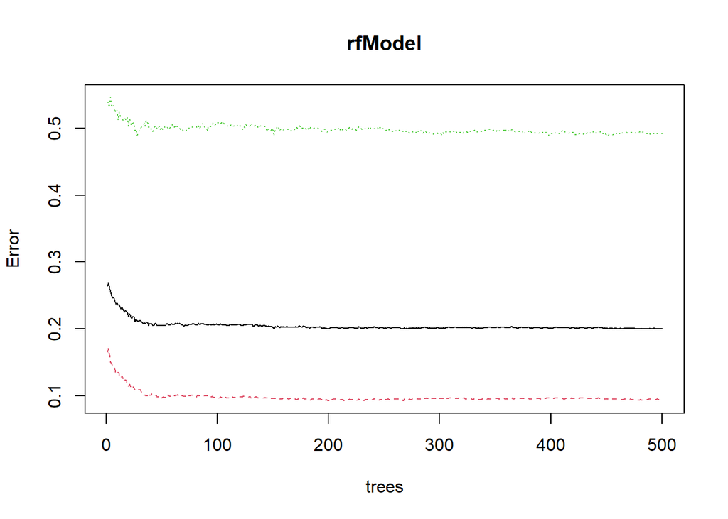

```r
plot(rfModel)
```

The plot showed that the optimal number of trees is from 100 to 200, so I try to tune the model.

# Fit the Random Forest Model after Tuning

```r
rfModel_new <- randomForest(Churn ~., data = training, ntree = 200, mtry = 2, importance = TRUE, proximity = TRUE)
print(rfModel_new)
```

```
##
## Call:
##  randomForest(formula = Churn ~ ., data = training, ntree = 200,      mtry = 2, importance = TRUE, proximity = TRUE)
##                Type of random forest: classification
##                      Number of trees: 200
## No. of variables tried at each split: 2
##
##         OOB estimate of  error rate: 19.76%
## Confusion matrix:
##       No Yes class.error
## No  3330 285  0.07883817
## Yes  688 621  0.52559206
```

```r
pred_rf_new <- predict(rfModel_new, testing)
table(Predicted = pred_rf_new, Actual = testing$Churn)
```

```
##          Actual
## Predicted    0    1
##       No  1430  327
##       Yes  118  233
```

```r
pred_rf_new_accuracy <- (1420+268)/(1420+292+128+268)
pred_rf_new_accuracy
```

[output not shown]

#Feature Importance according to the Random Forest model

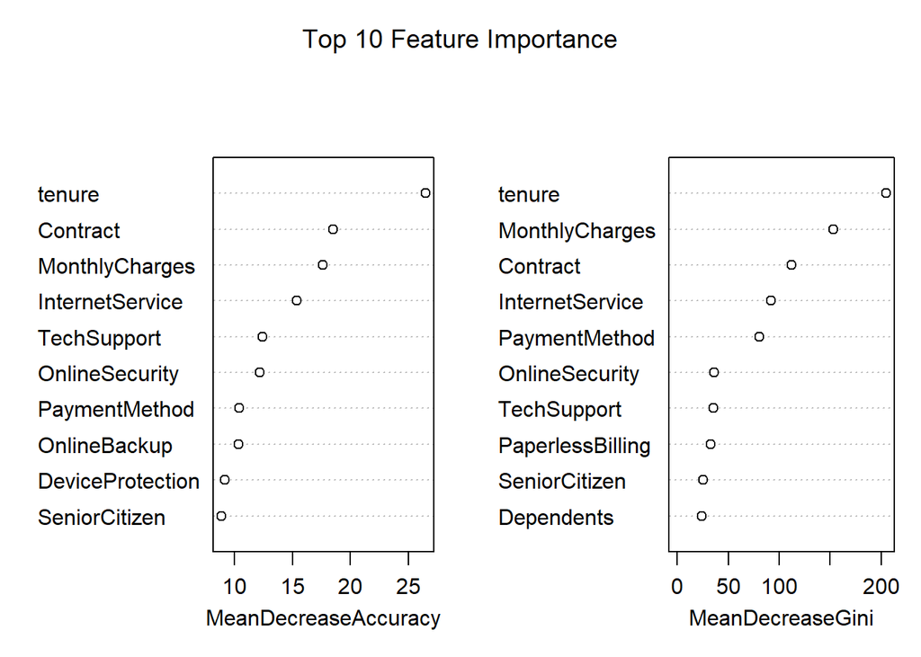

```r
varImpPlot(rfModel_new, sort=T,
    n.var = 10, main = 'Top 10 Feature Importance')
```

From the analysis, I can deduce that the most important features for determining customer churn is Tenure and Contract. The other important features are Paperless billing, Monthly charges, Internet Service.

Consumers that are on monthly contract with less than 2 month tenure are the most likely to churn. For the company to retain these customers, we need to find the characteristics that makes a customer want to retain the company subscriptions for more than 2 months. Then we can devise the products that encourage these customers to remain with the company.